# Welcome to Jupyter (a.k.a. Ipython Notebooks)

Take a while to adjust your bearings. Study the icons above.

There are two major types of cells:

1) Markdown cells - simple text. One can do html tags like **BOLD** or latex like $\beta$.

2) Code cells - cells where we can run code.

**Shortcuts**

1) CTRL-M then H to see help

2) CTRL-M then S to save notebook

3) CTRL-ENTER to Run Code but stay in the same cell

4) SHIFT-ENTER to Run Code and advance to the next cell

**Pro tip 1**

Using **%pylab inline** preceeding everything else in the notebook imports already matplotlib and numpy. It also enables our graphics to be part of the notebook.

**Pro tip 2** You can use TAB to see available functions. You can use SHIFT-TAB repeatedly for the documentation.

```python
%pylab inline
```

# Variables and Data Types

Let's explain the variables and data types here.

$$ h_i(x) = \sum_i^K(x_i) $$

```python
a = 1
b = 2.6
```

## Arithmetic

```python
a + b
```

```
3.6
```

```python
print a / 2
print a / 2.0
```

```
0
0.5
```

```python
a +=1
a
```

```
2
```

## Challenge! Write the following to code

$$ g(z) = \frac{1}{1+e^{-z}} $$

```python
1 / (1 + 2.718 ** 2)
```

```
0.1192246961081721
```

# Control Statements and Data Structures

## If Else

```python
lol = 'haha'

if lol == 'haha':
    print ("JOKE!")
else:
    print(":()")
```

```
JOKE!
```

## Lists

```python
list_a = [1, 2, 3, 4, 5]
list_a[1]
```

```
2
```

## Dict

```python
dict_a = {'first' : 1, 'second' : 2}
print (dict_a['first'])
print (list_a[dict_a['first']])
```

```
1
2
```

## Generators

```python
def gen_num_up_to(n):
    num = 0
    while num < n:
        yield num
        num +=1
```

```python
gen_num_up_to(5)
```

```
<generator object gen_num_up_to at 0x7ff92e83c500>
```

## List comprehension

```python
[v for v in gen_num_up_to(5)]
```

```
[0, 1, 2, 3, 4]
```

## For loop

Take note that `range` is also a generator.

range([start], stop, [step])

```python
[v for v in range(1, 100, 5)]
```

```
[1, 6, 11, 16, 21, 26, 31, 36, 41, 46, 51, 56, 61, 66, 71, 76, 81, 86, 91, 96]
```

```python
aggregator = []

for i in range(1, 5):
    aggregator.append([v for v in gen_num_up_to(5)])
aggregator
```

```
[[0, 1, 2, 3, 4], [0, 1, 2, 3, 4], [0, 1, 2, 3, 4], [0, 1, 2, 3, 4]]
```

## Slicing

```python
list_a = [1, 2, 3, 4, 5, 6, 7, 8, 9, 10]
list_a[:5]
```

```
[1, 2, 3, 4, 5]
```

```python
list_a[5:]
```

```
[6, 7, 8, 9, 10]
```

```python
list_a[:-2]
```

```
[1, 2, 3, 4, 5, 6, 7, 8]
```

```python
list_a[-2:]
```

```
[9, 10]
```

```python
list_a[2:8:2]
```

```
[3, 5, 7]
```

# Functions

Use the following notation:

def *function_name*:

```
 input commands here
```

Here is a sample function. np.random.randint(a, [b]) outputs uniformly random values from $[a,b) $

```python
def remainder(n, m):
    while True:
        if n - m < 0:
            return n
        else:
            n = n - m
```

```python
remainder(10, 4)
```

```
2
```

## Challenge: Coin Flip

Create a function that simulates coin flips repeated n times. Make the function a generator with a parameter n for the number of coin flips. Use np.random.randint to simulate a coin flip.

After defining this function, output a list using a list comprehension similar to the above example.

# Vectors, Matrices and Computation

```python
np.array(range(100))
```

```
array([ 0,  1,  2,  3,  4,  5,  6,  7,  8,  9, 10, 11, 12, 13, 14, 15, 16,
       17, 18, 19, 20, 21, 22, 23, 24, 25, 26, 27, 28, 29, 30, 31, 32, 33,
       34, 35, 36, 37, 38, 39, 40, 41, 42, 43, 44, 45, 46, 47, 48, 49, 50,
       51, 52, 53, 54, 55, 56, 57, 58, 59, 60, 61, 62, 63, 64, 65, 66, 67,
       68, 69, 70, 71, 72, 73, 74, 75, 76, 77, 78, 79, 80, 81, 82, 83, 84,
       85, 86, 87, 88, 89, 90, 91, 92, 93, 94, 95, 96, 97, 98, 99])
```

It's the same as just:

```python
np.arange(0, 100)
```

```
array([ 0,  1,  2,  3,  4,  5,  6,  7,  8,  9, 10, 11, 12, 13, 14, 15, 16,
       17, 18, 19, 20, 21, 22, 23, 24, 25, 26, 27, 28, 29, 30, 31, 32, 33,
       34, 35, 36, 37, 38, 39, 40, 41, 42, 43, 44, 45, 46, 47, 48, 49, 50,
       51, 52, 53, 54, 55, 56, 57, 58, 59, 60, 61, 62, 63, 64, 65, 66, 67,
       68, 69, 70, 71, 72, 73, 74, 75, 76, 77, 78, 79, 80, 81, 82, 83, 84,
       85, 86, 87, 88, 89, 90, 91, 92, 93, 94, 95, 96, 97, 98, 99])
```

```python
np.array([v for v in coin_flip(10)])
```

```
array([0, 1, 0, 0, 1, 0, 0, 1, 0, 1])
```

## Computing vector computations

### Vector to scalar

```python
array_a = np.arange(0, 5)
array_a * 2
```

```
array([0, 2, 4, 6, 8])
```

### Vector to vector: Dot Product

```python
array_a = np.arange(0,5)
array_b = np.arange(5,10)

print array_a
print array_b
print np.dot(array_a, array_b)
```

```
[0 1 2 3 4]
[5 6 7 8 9]
80
```

## Challenge: Compute the mean of 1000 coin flips

Recall that mean is computed thus:

$$ mean(\vec{X}) = \frac{1}{|\vec{X}|} \sum_{k}X_k$$

### Vector to vector: Element-wise multiplication

```python
array_a * array_b
```

```
array([ 0,  6, 14, 24, 36])
```

## Matrix to Scalar: Element-wise multiplication

```python
mat_a = np.random.randint(0, 5, size=(4,4))
print(mat_a)
print(mat_a * 2)
```

```
[[1 2 1 0]
 [4 1 3 3]
 [1 1 0 0]
 [2 4 3 1]]
[[2 4 2 0]
 [8 2 6 6]
 [2 2 0 0]
 [4 8 6 2]]
```

```python
mat_a * mat_a
```

```
array([[ 1,  4,  1,  0],
       [16,  1,  9,  9],
       [ 1,  1,  0,  0],
       [ 4, 16,  9,  1]])
```

## Advanced Matrix Operations

```python
from scipy.linalg import eig
eig(mat_a)
```

```
(array([ 6.37886691+0.j, -3.15634888+0.j,  0.29046325+0.j, -0.51298128+0.j]),
 array([[-0.27463123, -0.34528117, -0.40403003,  0.04088527],
        [-0.66495412,  0.78762688,  0.30823592,  0.35254379],
        [-0.14729659, -0.14014474, -0.32979769, -0.76694623],
        [-0.67876168, -0.49069773,  0.79560282,  0.53463515]]))
```

# Enter Pandas

```python
import pandas as pd

data = pd.read_csv("movie_metadata.csv")
```

```python
data.shape
```

```
(5044, 28)
```

```python
data.columns
```

```
Index([u'movie_title', u'color', u'director_name', u'num_critic_for_reviews',
       u'duration', u'director_facebook_likes', u'actor_3_facebook_likes',
       u'actor_2_name', u'actor_1_facebook_likes', u'gross', u'genres',
       u'actor_1_name', u'num_voted_users', u'cast_total_facebook_likes',
       u'actor_3_name', u'facenumber_in_poster', u'plot_keywords',
       u'movie_imdb_link', u'num_user_for_reviews', u'language', u'country',
       u'content_rating', u'budget', u'title_year', u'actor_2_facebook_likes',
       u'imdb_score', u'aspect_ratio', u'movie_facebook_likes'],
      dtype='object')
```

## Slicing data frames

```python
data[:4]
```

|  | movie_title | color | director_name | num_critic_for_reviews | duration | director_facebook_likes | actor_3_facebook_likes | actor_2_name | actor_1_facebook_likes | gross | ... | num_user_for_reviews | language | country | content_rating | budget | title_year | actor_2_facebook_likes | imdb_score | aspect_ratio | movie_facebook_likes |
| --- | --- | --- | --- | --- | --- | --- | --- | --- | --- | --- | --- | --- | --- | --- | --- | --- | --- | --- | --- | --- | --- |
| 0 | Avatar | Color | James Cameron | 723.0 | 178.0 | 0.0 | 855.0 | Joel David Moore | 1000.0 | 760505847.0 | ... | 3054.0 | English | USA | PG-13 | 237000000.0 | 2009.0 | 936.0 | 7.9 | 1.78 | 33000.0 |
| 1 | Pirates of the Caribbean: At World's End | Color | Gore Verbinski | 302.0 | 169.0 | 563.0 | 1000.0 | Orlando Bloom | 40000.0 | 309404152.0 | ... | 1238.0 | English | USA | PG-13 | 300000000.0 | 2007.0 | 5000.0 | 7.1 | 2.35 | 0.0 |
| 2 | Spectre | Color | Sam Mendes | 602.0 | 148.0 | 0.0 | 161.0 | Rory Kinnear | 11000.0 | 200074175.0 | ... | 994.0 | English | UK | PG-13 | 245000000.0 | 2015.0 | 393.0 | 6.8 | 2.35 | 85000.0 |
| 3 | The Dark Knight Rises | Color | Christopher Nolan | 813.0 | 164.0 | 22000.0 | 23000.0 | Christian Bale | 27000.0 | 448130642.0 | ... | 2701.0 | English | USA | PG-13 | 250000000.0 | 2012.0 | 23000.0 | 8.5 | 2.35 | 164000.0 |

4 rows × 28 columns

## Indexing Columns

```python
data.director_name[:4]
```

```
0        James Cameron
1       Gore Verbinski
2           Sam Mendes
3    Christopher Nolan
Name: director_name, dtype: object
```

```python
cols = ["movie_title","director_name"]
data[cols][:5]
```

|  | movie_title | director_name |
| --- | --- | --- |
| 0 | Avatar | James Cameron |
| 1 | Pirates of the Caribbean: At World's End | Gore Verbinski |
| 2 | Spectre | Sam Mendes |
| 3 | The Dark Knight Rises | Christopher Nolan |
| 4 | Star Wars: Episode VII - The Force Awakens ... | Doug Walker |

## Indexing Rows

```python
data.ix[10:12]
```

|  | movie_title | color | director_name | num_critic_for_reviews | duration | director_facebook_likes | actor_3_facebook_likes | actor_2_name | actor_1_facebook_likes | gross | ... | num_user_for_reviews | language | country | content_rating | budget | title_year | actor_2_facebook_likes | imdb_score | aspect_ratio | movie_facebook_likes |
| --- | --- | --- | --- | --- | --- | --- | --- | --- | --- | --- | --- | --- | --- | --- | --- | --- | --- | --- | --- | --- | --- |
| 10 | Batman v Superman: Dawn of Justice | Color | Zack Snyder | 673.0 | 183.0 | 0.0 | 2000.0 | Lauren Cohan | 15000.0 | 330249062.0 | ... | 3018.0 | English | USA | PG-13 | 250000000.0 | 2016.0 | 4000.0 | 6.9 | 2.35 | 197000.0 |
| 11 | Superman Returns | Color | Bryan Singer | 434.0 | 169.0 | 0.0 | 903.0 | Marlon Brando | 18000.0 | 200069408.0 | ... | 2367.0 | English | USA | PG-13 | 209000000.0 | 2006.0 | 10000.0 | 6.1 | 2.35 | 0.0 |
| 12 | Quantum of Solace | Color | Marc Forster | 403.0 | 106.0 | 395.0 | 393.0 | Mathieu Amalric | 451.0 | 168368427.0 | ... | 1243.0 | English | UK | PG-13 | 200000000.0 | 2008.0 | 412.0 | 6.7 | 2.35 | 0.0 |

3 rows × 28 columns

## Find Movies by James Cameron

```python
data[data.director_name == 'James Cameron']
```

|  | movie_title | color | director_name | num_critic_for_reviews | duration | director_facebook_likes | actor_3_facebook_likes | actor_2_name | actor_1_facebook_likes | gross | ... | num_user_for_reviews | language | country | content_rating | budget | title_year | actor_2_facebook_likes | imdb_score | aspect_ratio | movie_facebook_likes |
| --- | --- | --- | --- | --- | --- | --- | --- | --- | --- | --- | --- | --- | --- | --- | --- | --- | --- | --- | --- | --- | --- |
| 0 | Avatar | Color | James Cameron | 723.0 | 178.0 | 0.0 | 855.0 | Joel David Moore | 1000.0 | 760505847.0 | ... | 3054.0 | English | USA | PG-13 | 237000000.0 | 2009.0 | 936.0 | 7.9 | 1.78 | 33000.0 |
| 26 | Titanic | Color | James Cameron | 315.0 | 194.0 | 0.0 | 794.0 | Kate Winslet | 29000.0 | 658672302.0 | ... | 2528.0 | English | USA | PG-13 | 200000000.0 | 1997.0 | 14000.0 | 7.7 | 2.35 | 26000.0 |
| 288 | Terminator 2: Judgment Day | Color | James Cameron | 210.0 | 153.0 | 0.0 | 539.0 | Jenette Goldstein | 780.0 | 204843350.0 | ... | 983.0 | English | USA | R | 102000000.0 | 1991.0 | 604.0 | 8.5 | 2.35 | 13000.0 |
| 291 | True Lies | Color | James Cameron | 94.0 | 141.0 | 0.0 | 618.0 | Tia Carrere | 2000.0 | 146282411.0 | ... | 351.0 | English | USA | R | 115000000.0 | 1994.0 | 1000.0 | 7.2 | 2.35 | 0.0 |
| 606 | The Abyss | Color | James Cameron | 82.0 | 171.0 | 0.0 | 638.0 | Todd Graff | 2000.0 | 54222000.0 | ... | 380.0 | English | USA | PG-13 | 69500000.0 | 1989.0 | 650.0 | 7.6 | 2.35 | 0.0 |
| 2486 | Aliens | Color | James Cameron | 250.0 | 154.0 | 0.0 | 604.0 | Carrie Henn | 2000.0 | 85200000.0 | ... | 1076.0 | English | USA | R | 18500000.0 | 1986.0 | 626.0 | 8.4 | 1.85 | 18000.0 |
| 3575 | The Terminator | Color | James Cameron | 204.0 | 107.0 | 0.0 | 255.0 | Brian Thompson | 2000.0 | 38400000.0 | ... | 692.0 | English | UK | R | 6500000.0 | 1984.0 | 663.0 | 8.1 | 1.85 | 13000.0 |

7 rows × 28 columns

## Sort films by gross earnings

```python
sorted_data = data.sort_values(by="gross", ascending=False)
sorted_data[:5]
```

|  | movie_title | color | director_name | num_critic_for_reviews | duration | director_facebook_likes | actor_3_facebook_likes | actor_2_name | actor_1_facebook_likes | gross | ... | num_user_for_reviews | language | country | content_rating | budget | title_year | actor_2_facebook_likes | imdb_score | aspect_ratio | movie_facebook_likes |
| --- | --- | --- | --- | --- | --- | --- | --- | --- | --- | --- | --- | --- | --- | --- | --- | --- | --- | --- | --- | --- | --- |
| 0 | Avatar | Color | James Cameron | 723.0 | 178.0 | 0.0 | 855.0 | Joel David Moore | 1000.0 | 760505847.0 | ... | 3054.0 | English | USA | PG-13 | 237000000.0 | 2009.0 | 936.0 | 7.9 | 1.78 | 33000.0 |
| 26 | Titanic | Color | James Cameron | 315.0 | 194.0 | 0.0 | 794.0 | Kate Winslet | 29000.0 | 658672302.0 | ... | 2528.0 | English | USA | PG-13 | 200000000.0 | 1997.0 | 14000.0 | 7.7 | 2.35 | 26000.0 |
| 29 | Jurassic World | Color | Colin Trevorrow | 644.0 | 124.0 | 365.0 | 1000.0 | Judy Greer | 3000.0 | 652177271.0 | ... | 1290.0 | English | USA | PG-13 | 150000000.0 | 2015.0 | 2000.0 | 7.0 | 2.00 | 150000.0 |
| 794 | The Avengers | Color | Joss Whedon | 703.0 | 173.0 | 0.0 | 19000.0 | Robert Downey Jr. | 26000.0 | 623279547.0 | ... | 1722.0 | English | USA | PG-13 | 220000000.0 | 2012.0 | 21000.0 | 8.1 | 1.85 | 123000.0 |
| 17 | The Avengers | Color | Joss Whedon | 703.0 | 173.0 | 0.0 | 19000.0 | Robert Downey Jr. | 26000.0 | 623279547.0 | ... | 1722.0 | English | USA | PG-13 | 220000000.0 | 2012.0 | 21000.0 | 8.1 | 1.85 | 123000.0 |

5 rows × 28 columns

## Challenge! Get the top 5 films of Michael Bay

## Multiple Conditions: Find films from the Canada that have Hugh Jackman as the actor_1_name

```python
data[(data['country'] == 'Canada') & (data['actor_1_name'] == 'Hugh Jackman')]
```

|  | movie_title | color | director_name | num_critic_for_reviews | duration | director_facebook_likes | actor_3_facebook_likes | actor_2_name | actor_1_facebook_likes | gross | ... | num_user_for_reviews | language | country | content_rating | budget | title_year | actor_2_facebook_likes | imdb_score | aspect_ratio | movie_facebook_likes |
| --- | --- | --- | --- | --- | --- | --- | --- | --- | --- | --- | --- | --- | --- | --- | --- | --- | --- | --- | --- | --- | --- |
| 34 | X-Men: The Last Stand | Color | Brett Ratner | 334.0 | 104.0 | 420.0 | 560.0 | Kelsey Grammer | 20000.0 | 234360014.0 | ... | 1912.0 | English | Canada | PG-13 | 210000000.0 | 2006.0 | 808.0 | 6.8 | 2.35 | 0.0 |
| 210 | X-Men 2 | Color | Bryan Singer | 289.0 | 134.0 | 0.0 | 346.0 | Bruce Davison | 20000.0 | 214948780.0 | ... | 1055.0 | English | Canada | PG-13 | 110000000.0 | 2003.0 | 505.0 | 7.5 | 2.35 | 0.0 |

2 rows × 28 columns

## Challenge! Find the actor who is the actor_1_name for the movie that grossed exactly 67344392. Then, find films whose actor_3_name is Piolo Pascual and actor_1_name is the person from Armageddon.

# Preprocessing

```python
data.dtypes
```

```
movie_title                   object
color                         object
director_name                 object
num_critic_for_reviews       float64
duration                     float64
director_facebook_likes      float64
actor_3_facebook_likes       float64
actor_2_name                  object
actor_1_facebook_likes       float64
gross                        float64
genres                        object
actor_1_name                  object
num_voted_users              float64
cast_total_facebook_likes    float64
actor_3_name                  object
facenumber_in_poster         float64
plot_keywords                 object
movie_imdb_link               object
num_user_for_reviews         float64
language                      object
country                       object
content_rating                object
budget                       float64
title_year                   float64
actor_2_facebook_likes       float64
imdb_score                   float64
aspect_ratio                 float64
movie_facebook_likes         float64
dtype: object
```

## Convert actor_1_facebook_likes to integers

```python
# will have an error
# data.actor_1_facebook_likes.astype(np.int64)
```

```python
data['actor_1_facebook_likes'] = data['actor_1_facebook_likes'].fillna(0)
data['actor_1_facebook_likes'] = data['actor_1_facebook_likes'].astype(np.int64)
data.dtypes
```

```
movie_title                   object
color                         object
director_name                 object
num_critic_for_reviews       float64
duration                     float64
director_facebook_likes      float64
actor_3_facebook_likes       float64
actor_2_name                  object
actor_1_facebook_likes         int64
gross                        float64
genres                        object
actor_1_name                  object
num_voted_users              float64
cast_total_facebook_likes    float64
actor_3_name                  object
facenumber_in_poster         float64
plot_keywords                 object
movie_imdb_link               object
num_user_for_reviews         float64
language                      object
country                       object
content_rating                object
budget                       float64
title_year                   float64
actor_2_facebook_likes       float64
imdb_score                   float64
aspect_ratio                 float64
movie_facebook_likes         float64
dtype: object
```

## Apply function for each cell

Actually, one can think of a lambda as a nameless function.

```python
data.actor_1_facebook_likes.apply(lambda x: np.sqrt(x))[:5]
```

```
0     31.622777
1    200.000000
2    104.880885
3    164.316767
4     11.445523
Name: actor_1_facebook_likes, dtype: float64
```

## Clean titles

```python
data.movie_title.tolist()[:5]
```

```
['Avatar\xc2\xa0',
 "Pirates of the Caribbean: At World's End\xc2\xa0",
 'Spectre\xc2\xa0',
 'The Dark Knight Rises\xc2\xa0',
 'Star Wars: Episode VII - The Force Awakens\xc2\xa0            ']
```

```python
data.movie_title[:10].apply(
    lambda x: x.decode('unicode_escape').encode('ascii','ignore')).tolist()
```

```
['Avatar',
 "Pirates of the Caribbean: At World's End",
 'Spectre',
 'The Dark Knight Rises',
 'Star Wars: Episode VII - The Force Awakens            ',
 'John Carter',
 'Spider-Man 3',
 'Tangled',
 'Avengers: Age of Ultron',
 'Harry Potter and the Half-Blood Prince']
```

```python
# a weakness though is that it removes enye
print data[data.movie_title.str.contains("ñ")]["movie_title"]
print("The following removed the enye:")
print data[data.movie_title.str.contains("ñ")]["movie_title"].apply(
    lambda x: x.decode('unicode_escape').encode('ascii','ignore')).tolist()
```

```
4796    Quinceañera
Name: movie_title, dtype: object
The following removed the enye:
['Quinceaera']
```

```python
data["movie_title"] = data["movie_title"].apply(
    lambda x: x.decode('unicode_escape').encode('ascii','ignore'))
```

## Clean all

Replace values with 0. Of course, imputation could be done here, but other libraries are need for it.

We are adding a new reference to the original data. Only the new cells are allocated memory. The unchanged cells are referenced to the original.

```python
cleaned_data = data.fillna(0)
```

## Data Summaries

```python
cleaned_data.describe()
```

|  | num_critic_for_reviews | duration | director_facebook_likes | actor_3_facebook_likes | actor_1_facebook_likes | gross | num_voted_users | cast_total_facebook_likes | facenumber_in_poster | num_user_for_reviews | budget | title_year | actor_2_facebook_likes | imdb_score | aspect_ratio | movie_facebook_likes |
| --- | --- | --- | --- | --- | --- | --- | --- | --- | --- | --- | --- | --- | --- | --- | --- | --- |
| count | 5044.000000 | 5044.000000 | 5044.000000 | 5044.000000 | 5044.000000 | 5.044000e+03 | 5.044000e+03 | 5044.000000 | 5044.000000 | 5044.000000 | 5.044000e+03 | 5044.000000 | 5044.000000 | 5044.000000 | 5044.000000 | 5044.000000 |
| mean | 138.776764 | 106.861023 | 672.218279 | 641.940722 | 6549.642546 | 3.996434e+07 | 8.365157e+04 | 9697.140960 | 1.367367 | 271.581086 | 3.586720e+07 | 1959.596749 | 1647.169905 | 6.440860 | 2.075135 | 7524.472443 |
| std | 121.795659 | 25.869713 | 2785.611681 | 1661.668020 | 15011.110715 | 6.483380e+07 | 1.384765e+05 | 18162.511577 | 2.012073 | 377.585698 | 1.961367e+08 | 290.153085 | 4037.759216 | 1.128655 | 1.447240 | 19318.820075 |
| min | 0.000000 | 0.000000 | 0.000000 | 0.000000 | 0.000000 | 0.000000e+00 | 0.000000e+00 | 0.000000 | 0.000000 | 0.000000 | 0.000000e+00 | 0.000000 | 0.000000 | 0.000000 | 0.000000 | 0.000000 |
| 25% | 48.000000 | 93.000000 | 6.000000 | 130.000000 | 611.000000 | 3.031302e+05 | 8.581750e+03 | 1411.000000 | 0.000000 | 64.000000 | 3.000000e+06 | 1998.000000 | 278.000000 | 5.800000 | 1.850000 | 0.000000 |
| 50% | 108.500000 | 103.000000 | 45.000000 | 367.000000 | 985.500000 | 1.522984e+07 | 3.435750e+04 | 3090.000000 | 1.000000 | 155.000000 | 1.500000e+07 | 2005.000000 | 595.000000 | 6.600000 | 1.850000 | 165.500000 |
| 75% | 194.000000 | 118.000000 | 189.000000 | 635.000000 | 11000.000000 | 5.133721e+07 | 9.627100e+04 | 13754.250000 | 2.000000 | 324.000000 | 4.000000e+07 | 2011.000000 | 918.000000 | 7.200000 | 2.350000 | 3000.000000 |
| max | 813.000000 | 511.000000 | 23000.000000 | 23000.000000 | 640000.000000 | 7.605058e+08 | 1.689764e+06 | 656730.000000 | 43.000000 | 5060.000000 | 1.221550e+10 | 2016.000000 | 137000.000000 | 9.500000 | 16.000000 | 349000.000000 |

## Data Correlations

```python
cleaned_data.corr()
```

|  | num_critic_for_reviews | duration | director_facebook_likes | actor_3_facebook_likes | actor_1_facebook_likes | gross | num_voted_users | cast_total_facebook_likes | facenumber_in_poster | num_user_for_reviews | budget | title_year | actor_2_facebook_likes | imdb_score | aspect_ratio | movie_facebook_likes |
| --- | --- | --- | --- | --- | --- | --- | --- | --- | --- | --- | --- | --- | --- | --- | --- | --- |
| num_critic_for_reviews | 1.000000 | 0.269957 | 0.184942 | 0.273130 | 0.193322 | 0.524884 | 0.626649 | 0.266189 | -0.033755 | 0.612024 | 0.127874 | 0.153370 | 0.284396 | 0.299959 | 0.055258 | 0.682596 |
| duration | 0.269957 | 1.000000 | 0.161057 | 0.123878 | 0.089381 | 0.254773 | 0.313770 | 0.123360 | 0.004985 | 0.329757 | 0.074785 | 0.261492 | 0.131934 | 0.259765 | -0.016001 | 0.195677 |
| director_facebook_likes | 0.184942 | 0.161057 | 1.000000 | 0.121308 | 0.092385 | 0.149975 | 0.298072 | 0.121131 | -0.041191 | 0.223910 | 0.024609 | 0.032851 | 0.121085 | 0.162214 | 0.006091 | 0.162117 |
| actor_3_facebook_likes | 0.273130 | 0.123878 | 0.121308 | 1.000000 | 0.250455 | 0.321765 | 0.287906 | 0.474367 | 0.100510 | 0.231251 | 0.051278 | 0.032404 | 0.559993 | 0.052168 | 0.021094 | 0.279254 |
| actor_1_facebook_likes | 0.193322 | 0.089381 | 0.092385 | 0.250455 | 1.000000 | 0.167355 | 0.193137 | 0.951672 | 0.072998 | 0.146831 | 0.027301 | 0.054483 | 0.390789 | 0.076080 | 0.001651 | 0.135558 |
| gross | 0.524884 | 0.254773 | 0.149975 | 0.321765 | 0.167355 | 1.000000 | 0.651554 | 0.259799 | -0.023865 | 0.582966 | 0.123523 | 0.093693 | 0.284105 | 0.176566 | 0.026066 | 0.392661 |
| num_voted_users | 0.626649 | 0.313770 | 0.298072 | 0.287906 | 0.193137 | 0.651554 | 1.000000 | 0.265958 | -0.026623 | 0.798766 | 0.087497 | 0.058642 | 0.271243 | 0.410305 | 0.045424 | 0.537943 |
| cast_total_facebook_likes | 0.266189 | 0.123360 | 0.121131 | 0.474367 | 0.951672 | 0.259799 | 0.265958 | 1.000000 | 0.091973 | 0.208067 | 0.041856 | 0.059912 | 0.628616 | 0.086112 | 0.010541 | 0.209818 |
| facenumber_in_poster | -0.033755 | 0.004985 | -0.041191 | 0.100510 | 0.072998 | -0.023865 | -0.026623 | 0.091973 | 1.000000 | -0.068176 | -0.018937 | -0.018798 | 0.072320 | -0.061238 | 0.002017 | 0.007873 |
| num_user_for_reviews | 0.612024 | 0.329757 | 0.223910 | 0.231251 | 0.146831 | 0.582966 | 0.798766 | 0.208067 | -0.068176 | 1.000000 | 0.093058 | 0.072690 | 0.220675 | 0.289641 | 0.045000 | 0.401228 |
| budget | 0.127874 | 0.074785 | 0.024609 | 0.051278 | 0.027301 | 0.123523 | 0.087497 | 0.041856 | -0.018937 | 0.093058 | 1.000000 | 0.028274 | 0.048909 | 0.025891 | 0.007470 | 0.066176 |
| title_year | 0.153370 | 0.261492 | 0.032851 | 0.032404 | 0.054483 | 0.093693 | 0.058642 | 0.059912 | -0.018798 | 0.072690 | 0.028274 | 1.000000 | 0.047642 | -0.155797 | -0.367360 | 0.033245 |
| actor_2_facebook_likes | 0.284396 | 0.131934 | 0.121085 | 0.559993 | 0.390789 | 0.284105 | 0.271243 | 0.628616 | 0.072320 | 0.220675 | 0.048909 | 0.047642 | 1.000000 | 0.083593 | 0.020407 | 0.243722 |
| imdb_score | 0.299959 | 0.259765 | 0.162214 | 0.052168 | 0.076080 | 0.176566 | 0.410305 | 0.086112 | -0.061238 | 0.289641 | 0.025891 | -0.155797 | 0.083593 | 1.000000 | 0.095499 | 0.246687 |
| aspect_ratio | 0.055258 | -0.016001 | 0.006091 | 0.021094 | 0.001651 | 0.026066 | 0.045424 | 0.010541 | 0.002017 | 0.045000 | 0.007470 | -0.367360 | 0.020407 | 0.095499 | 1.000000 | 0.060339 |
| movie_facebook_likes | 0.682596 | 0.195677 | 0.162117 | 0.279254 | 0.135558 | 0.392661 | 0.537943 | 0.209818 | 0.007873 | 0.401228 | 0.066176 | 0.033245 | 0.243722 | 0.246687 | 0.060339 | 1.000000 |

## Outliers : Clipping to the 99th percentile

This is just one of the many rules-of-thumb used in practice. It doesn't always work, especially if one has too many outliers.

```python
cleaned_data.duration.quantile(0.99)
```

```
189.0
```

```python
cleaned_data['duration'] = np.clip(cleaned_data['duration'], 0, 189)
cleaned_data.describe()
```

|  | num_critic_for_reviews | duration | director_facebook_likes | actor_3_facebook_likes | actor_1_facebook_likes | gross | num_voted_users | cast_total_facebook_likes | facenumber_in_poster | num_user_for_reviews | budget | title_year | actor_2_facebook_likes | imdb_score | aspect_ratio | movie_facebook_likes |
| --- | --- | --- | --- | --- | --- | --- | --- | --- | --- | --- | --- | --- | --- | --- | --- | --- |
| count | 5044.000000 | 5044.000000 | 5044.000000 | 5044.000000 | 5044.000000 | 5.044000e+03 | 5.044000e+03 | 5044.000000 | 5044.000000 | 5044.000000 | 5.044000e+03 | 5044.000000 | 5044.000000 | 5044.000000 | 5044.000000 | 5044.000000 |
| mean | 138.776764 | 106.411975 | 672.218279 | 641.940722 | 6549.642546 | 3.996434e+07 | 8.365157e+04 | 9697.140960 | 1.367367 | 271.581086 | 3.586720e+07 | 1959.596749 | 1647.169905 | 6.440860 | 2.075135 | 7524.472443 |
| std | 121.795659 | 23.327743 | 2785.611681 | 1661.668020 | 15011.110715 | 6.483380e+07 | 1.384765e+05 | 18162.511577 | 2.012073 | 377.585698 | 1.961367e+08 | 290.153085 | 4037.759216 | 1.128655 | 1.447240 | 19318.820075 |
| min | 0.000000 | 0.000000 | 0.000000 | 0.000000 | 0.000000 | 0.000000e+00 | 0.000000e+00 | 0.000000 | 0.000000 | 0.000000 | 0.000000e+00 | 0.000000 | 0.000000 | 0.000000 | 0.000000 | 0.000000 |
| 25% | 48.000000 | 93.000000 | 6.000000 | 130.000000 | 611.000000 | 3.031302e+05 | 8.581750e+03 | 1411.000000 | 0.000000 | 64.000000 | 3.000000e+06 | 1998.000000 | 278.000000 | 5.800000 | 1.850000 | 0.000000 |
| 50% | 108.500000 | 103.000000 | 45.000000 | 367.000000 | 985.500000 | 1.522984e+07 | 3.435750e+04 | 3090.000000 | 1.000000 | 155.000000 | 1.500000e+07 | 2005.000000 | 595.000000 | 6.600000 | 1.850000 | 165.500000 |
| 75% | 194.000000 | 118.000000 | 189.000000 | 635.000000 | 11000.000000 | 5.133721e+07 | 9.627100e+04 | 13754.250000 | 2.000000 | 324.000000 | 4.000000e+07 | 2011.000000 | 918.000000 | 7.200000 | 2.350000 | 3000.000000 |
| max | 813.000000 | 189.000000 | 23000.000000 | 23000.000000 | 640000.000000 | 7.605058e+08 | 1.689764e+06 | 656730.000000 | 43.000000 | 5060.000000 | 1.221550e+10 | 2016.000000 | 137000.000000 | 9.500000 | 16.000000 | 349000.000000 |

## Output to CSV file

```python
cleaned_data.to_csv('movie_metadata_cleaned.csv')
```

```python
!head -n 2 movie_metadata_cleaned.csv
```

```
,movie_title,color,director_name,num_critic_for_reviews,duration,director_facebook_likes,actor_3_facebook_likes,actor_2_name,actor_1_facebook_likes,gross,genres,actor_1_name,num_voted_users,cast_total_facebook_likes,actor_3_name,facenumber_in_poster,plot_keywords,movie_imdb_link,num_user_for_reviews…
0,Avatar,Color,James Cameron,723.0,178.0,0.0,855.0,Joel David Moore,1000,760505847.0,Action|Adventure|Fantasy|Sci-Fi,CCH Pounder,886204.0,4834.0,Wes Studi,0.0,avatar|future|marine|native|paraplegic,http://www.imdb.com/title/tt0499549/?ref_=fn_tt_tt_1,3054.0,English,USA,PG-13,237000000.0,2009.0,936.0…
```

# Aggregations

In this example, the group by statement does two things:

1) groups together the dataframe by title_year

2) the size() function has the title_year as the index

```python
cleaned_data["title_year"] = cleaned_data["title_year"].astype(np.int64)
movies_per_year = cleaned_data.groupby("title_year").size()
movies_per_year[-5:]
```

```
title_year
2012    221
2013    237
2014    253
2015    226
2016    106
dtype: int64
```

```python
like_per_year = cleaned_data.groupby("title_year")["movie_facebook_likes"].mean()
like_per_year[-5:]
```

```
title_year
2012    24259.004525
2013    25115.805907
2014    19850.422925
2015    19775.920354
2016    17610.669811
Name: movie_facebook_likes, dtype: float64
```

# Data Visualization

## Matplotlib: Line Plot : Average Facebook Likes per Year

Plot takes in as the first parameter the x axis and the second, the y axis values.

plt.figure(figsize=(15,8)) is just the size of the plot.

```python
# we're preempting seaborn for a better look-and-feel of the plots
import seaborn as sns
```

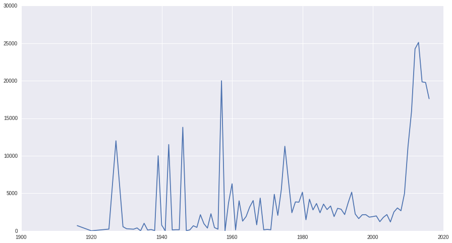

```python
fig = plt.figure(figsize=(15,8))
years = like_per_year.index.tolist()[1:]
likes = like_per_year[1:]
plt.plot(years, likes)
plt.show()
```

## Matplotlib: Scatterplot : Gross VS Budget

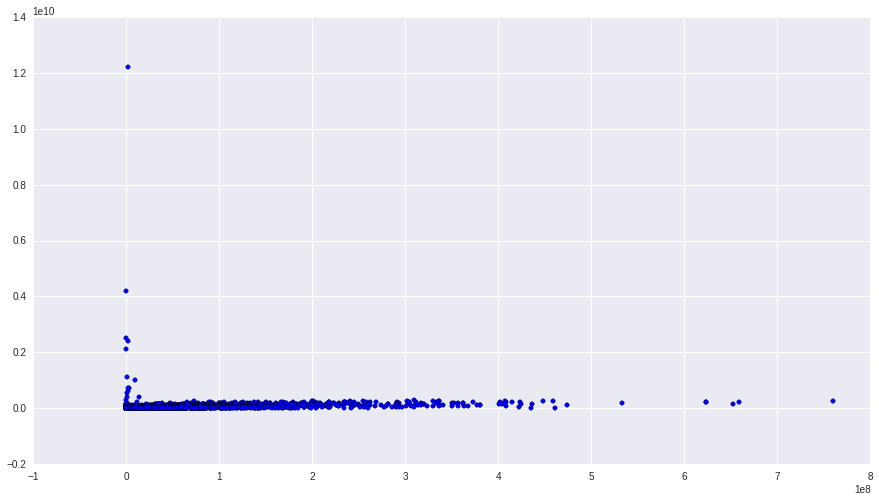

```python
fig = plt.figure(figsize=(15,8))
plt.scatter(cleaned_data["gross"], cleaned_data["budget"])
plt.show()
```

## Matplotlib: Histogram of IMDB scores

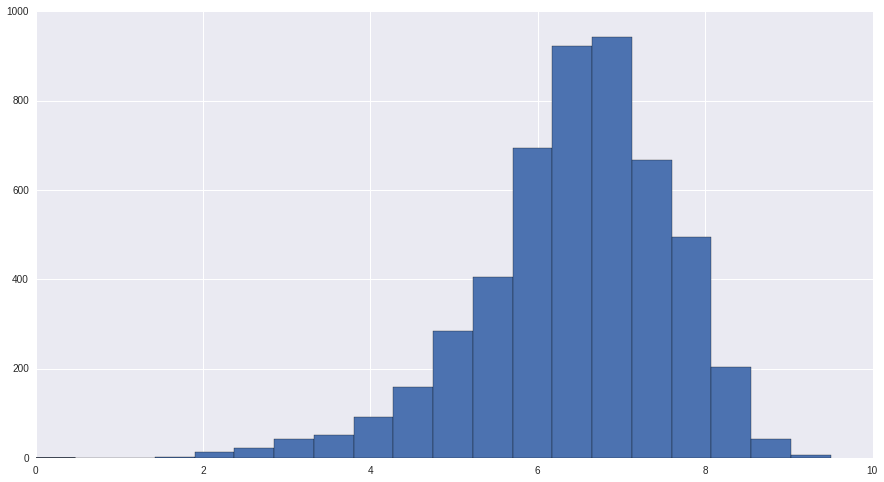

```python
fig = plt.figure(figsize=(15,8))
plt.hist(cleaned_data["imdb_score"], bins=20)
plt.show()
```

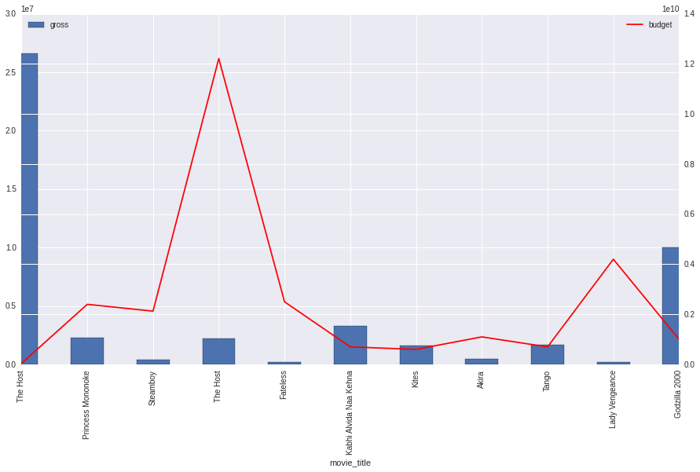

```python
top_budget = cleaned_data.sort_values(by="budget", ascending=False)["movie_title"][:10].tolist()
top_budget_data = cleaned_data[cleaned_data["movie_title"].isin(top_budget)]

ax1 = top_budget_data.plot(x="movie_title", y="gross", kind="bar", figsize=(15,8))
ax2 = ax1.twinx()
top_budget_data.plot(x="movie_title", y="budget", kind="line",
                     color='red', figsize=(15,8), ax=ax2)
ax1.legend(loc='upper left')
ax2.legend(loc='upper right')
plt.show()
```

## Plot the histograms of imdb_scores according to different content rating Types

We're finding out which content type tends to have the higher imdb_score.

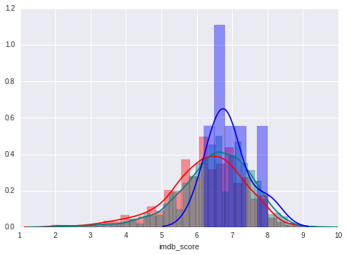

```python
import seaborn as sns

ax = sns.distplot(cleaned_data[cleaned_data['content_rating'] == 'PG-13']["imdb_score"],
                  color='red')
sns.distplot(cleaned_data[cleaned_data['content_rating'] == 'R']["imdb_score"],
             color='teal', ax=ax)
sns.distplot(cleaned_data[cleaned_data['content_rating'] == 'GP']["imdb_score"],
             color='blue', ax=ax)
```

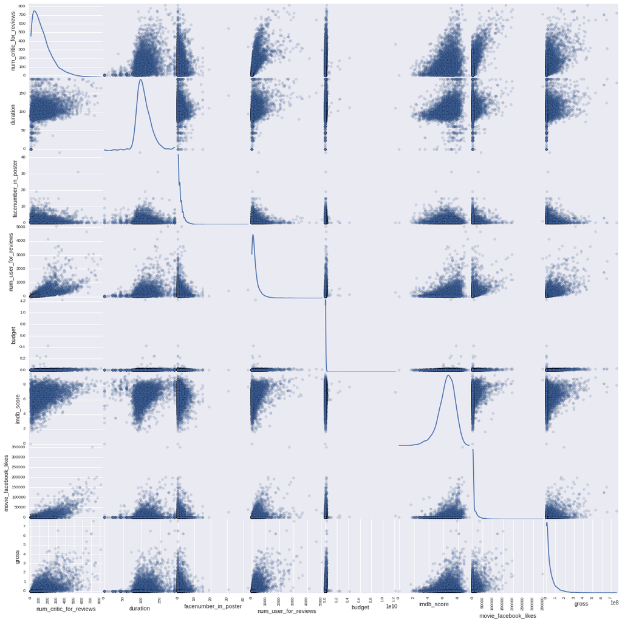

```python
from pandas.tools.plotting import scatter_matrix
cols = ["num_critic_for_reviews", "duration", "facenumber_in_poster",
        "num_user_for_reviews", "budget", "imdb_score", "movie_facebook_likes", "gross"]
scatter_matrix(cleaned_data[cols], alpha=0.2, figsize=(20, 20),
               diagonal='kde', marker='o')
plt.show()
```

## Seaborn : Conditional Formatting

For more, check out: https://pandas.pydata.org/pandas-docs/stable/style.html

```python
import seaborn as sns

cm = sns.light_palette("green", as_cmap=True)
cols = ["movie_title", "imdb_score","gross"]
color_me = cleaned_data[cols][:10]
s = color_me.style.background_gradient(cmap=cm)
s
```

|  | movie_title | imdb_score | gross |
| --- | --- | --- | --- |
| 0 | Avatar | 7.9 | 7.60506e+08 |
| 1 | Pirates of the Caribbean: At World's End | 7.1 | 3.09404e+08 |
| 2 | Spectre | 6.8 | 2.00074e+08 |
| 3 | The Dark Knight Rises | 8.5 | 4.48131e+08 |
| 4 | Star Wars: Episode VII - The Force Awakens | 7.1 | 0 |
| 5 | John Carter | 6.6 | 7.30587e+07 |
| 6 | Spider-Man 3 | 6.2 | 3.3653e+08 |
| 7 | Tangled | 7.8 | 2.00807e+08 |
| 8 | Avengers: Age of Ultron | 7.5 | 4.58992e+08 |
| 9 | Harry Potter and the Half-Blood Prince | 7.5 | 3.01957e+08 |

## Advanced Graphs: Plotting more than 2 variables

Let's take this slowly.

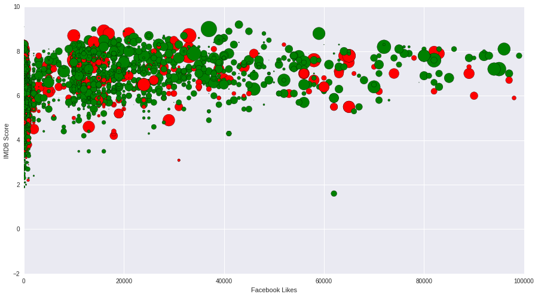

```python
plt.figure(figsize=(15,8))
sizes = 1000*((cleaned_data["gross"] - min(cleaned_data["gross"]))
              / max(cleaned_data["gross"] ) - min(cleaned_data["gross"] ))
colors = np.where(cleaned_data.genres.str.contains("Fantasy"), 'red', 'green')
plt.scatter(x=cleaned_data["movie_facebook_likes"],
            y=cleaned_data["imdb_score"], c=colors,
            s = sizes)

plt.xlabel("Facebook Likes")
plt.ylabel("IMDB Score")
plt.xlim((0,100000))
plt.show()
```

## Seaborn : Line Plot with Regression : Voted users and reviews

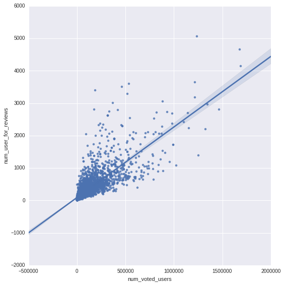

```python
sns.lmplot(x="num_voted_users", y="num_user_for_reviews", data=cleaned_data, size=8)
```

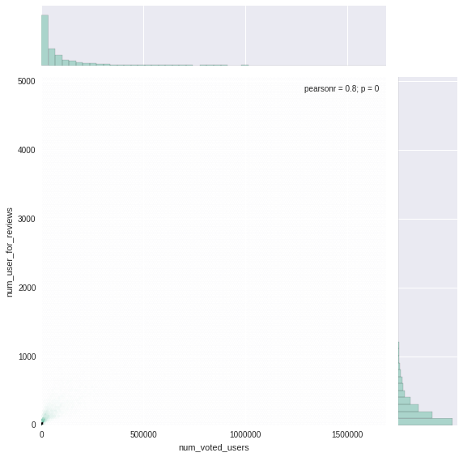

```python
sns.jointplot(x="num_voted_users", y="num_user_for_reviews", data=cleaned_data, size=8,
             kind="hex", color="#4CB391")
```

## Challenge! Fix the above plot by clipping by the Tukey's Test (k=1):

Use the np.clip function to bound the results as the following interval: $$ {\big [}Q_{1}-k(Q_{3}-Q_{1}),Q_{3}+k(Q_{3}-Q_{1}){\big ]} $$

## Seaborn : Barplot of the gross earnings of the last 10 years

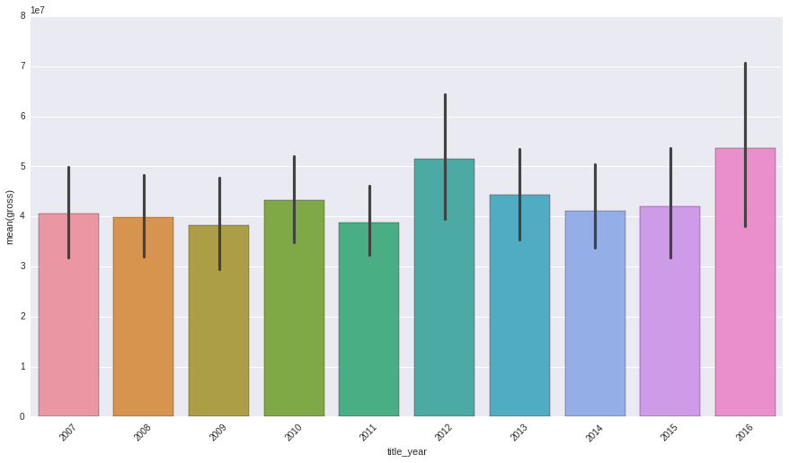

```python
cleaned_data["title_year"] = cleaned_data["title_year"].astype(np.int64)
latest_10_years = np.sort(cleaned_data["title_year"].unique())[-10:]

latest_movies_data=cleaned_data[cleaned_data["title_year"].isin(latest_10_years)]
plt.figure(figsize=(15,8))
sns.barplot(x="title_year", y="gross", data=latest_movies_data)
plt.xticks(rotation=45)
plt.show()
```

## Challenge : Get the top 10 directors with most movies directed and use a boxplot for their gross earnings

# Afternoon Activities

## Plot the following variables in one graph:

- num_critic_for_reviews
- IMDB score
- gross
- Steven Spielberg against others

## Compute Sales (Gross - Budget), add it as another column

## Which directors garnered the most total sales?

## Which actors garnered the most total sales?

## Plot sales as a function of movie_facebook_likes. Plot it as a scatterplot. Fit it with a line.

1. Create a function for the Tukey's method above
2. Remove sales and movie_facebook_like outliers for a better understanding.
3. Add jitter.
4. Is there a good linear correlation?
5. Bonus: Try a nonlinear fit, i.e. polynomial of order 2, 3, 4?

## Which of these genres are the most profitable? Plot their sales using different histograms, superimposed in the same axis.

- Romance
- Comedy
- Action
- Fantasy

## Plot a Kernel Density Estimation plot of the following variable combinations:

1. Duration and Gross
2. Duration and IMDB Scores

To review, for clearer plotting, you have the following options:

1. Sampling - research on this
2. Jittering
3. Outlier removal

## Standardization

Standardize sales using the following formula then save it to a new column.

$$ Z={X-\operatorname {E} [X] \over \sigma (X)} $$

The first values should be: [2.612646, 0.026695, -0.246587, 0.975996, -0.020609]

## For each of movie, compute average likes of the three actors and store it as a new variable. Standardize. Read up on the mean function.

Store it as a new column, average_actor_likes.

## Create a linear hypothesis function

Create a function that takes (1) a scalar, (2) theta and (3) a bias variable to output a value as close as possible to gross.

$$ score = b + \sum_j{(\theta_j * x)} $$$$ score = \theta_1 * average\_actor\_likes + bias $$

## Create an RMSE function

Create a function that compares two vectors and outputs the root mean squared error / deviation.

$$ \operatorname{RMSD}(\hat{\theta}) = \sqrt{\operatorname{MSE}(\hat{\theta})} = \sqrt{\operatorname{E}((\hat{\theta}-\theta)^2)} $$

## Create the best possible thetas by brute-forcing against the RMSE function.

Create predictions for your entire dataset. Compare your predictions against the score. Achieve the smallest RMSE you can.

## Plot your best theta, bias variable against the imdb score for each movie

For a cleaner plot:

(1) compile your average_actor_likes, imdb_scores and predicted to a new dataframe

(2) limit the bounds of your predicted ratings

## Convert your hypothesis function to use more variables:

Don't forget to standardize your new variables.

$$ score = \theta_1 * average\_actor\_likes + \theta_2 * movie\_facebook\_likes + \theta_3 * sales + bias $$

## Compile your theta values to a new pandas dataframe which consists of the following columns:

| 0.1 | 0.1 | 0.1 | 10000 |
| --- | --- | --- | --- |
| 0.2 | 0.2 | 0.2 | 2000 |

## Plot how each theta parameter influence the RMSE. Which one seems to be most influential?

# Backup Activities

## Using Linear Regression (Ridge)

Find the best coefficients using Ridge regression. Don't forget to normalize your variables.